# Indicadores del índice de Calidad del Entorno

Análisis espacial utilizando Índice de Calidad del Entorno (ICE)

Diana Villasana Ocampo

## Índice de Calidad del Entorno

El **Índice de Calidad del Entorno (ICE)**, desarrollado por el Consejo Nacional de Población (CONAPO), es un indicador compuesto que busca medir las características de los asentamientos humanos en México, tomando en cuenta factores como la marginación, la disponibilidad de servicios y equipamiento urbano. Su objetivo principal es ofrecer información que sintetice los factores contextuales negativos que limitan la participación e inclusión de las personas, especialmente aquellas con discapacidad.

**Dimensiones del ICE:**

El ICE se estructura en tres dimensiones principales:

El ICE es una herramienta útil para:

- **Identificar áreas con mayores carencias:** Permite identificar las zonas donde se concentran los factores que limitan la calidad del entorno, lo que puede ser útil para la toma de decisiones en políticas públicas.
- **Evaluar el impacto de políticas públicas:** El ICE puede ser utilizado para evaluar el impacto de programas y políticas públicas en la calidad del entorno.
- **Promover la inclusión:** Al visibilizar los factores que limitan la inclusión de las personas, el ICE puede contribuir a la promoción de políticas que mejoren la calidad de vida de todos los ciudadanos.

**Limitaciones del ICE:**

Es importante tener en cuenta que el ICE tiene algunas limitaciones:

- **Disponibilidad de información:** La disponibilidad de información para calcular el ICE puede ser limitada en algunas zonas.
- **Complejidad del fenómeno:** La calidad del entorno es un fenómeno complejo que no puede ser abarcado en su totalidad por un solo indicador.

## Shapefiles

### .shp

La función `readOGR` del paquete `rgdal`, extrae automáticamente la información utilizada por otros paquetes `SIG` de código abierto como QGIS y permite a `R` manejar una gama más amplia de formatos de datos espaciales. Esta función lee datos `OGR` y datos vectoriales, pero solamente permite manejar capas con características geométricas (no mezcla puntos, líneas o polígonos en una sola capa) y a su vez establecerá un sistema de referencia espacial si la capa tiene dichos metadatos.  
Para leer un archivo `shapefile`, se establecen los siguientes argumentos, como `dsn`, en donde se indica el directorio que contiene los shapes y `layer` que es el nombre explícito de la capa a trabajar y dichas capas deben de ir sin la extensión `.shp`.

A continuación se lee el archivo `.shp` que contiene de manera integrada la división de el área geoestadística estatal `agee`.

```r
shape_estados <- readOGR(dsn ="D:/MGN/MGN 2020/MGN 2020/conjunto_de_datos",
                             layer = "00ent",
                              encoding = "UTF-8",
                               use_iconv = TRUE)
```

Se lee el archivo .shp que contiene de manera integrada la división de el área geoestadística municipal `agem`

```r
shape_municipios <- readOGR(dsn ="D:/MGN/MGN 2020/MGN 2020/conjunto_de_datos",
                             layer = "00mun",
                              encoding = "UTF-8",
                               use_iconv = TRUE)
```

**Shapefile localidades (polígonos) 2020**

La función `rename()` del paquete `dplyr` permite cambiar el nombre de la columna de la clave geoestadística a nivel localidad dentro de la base de datos del shape.

A continuación se lee el archivo .shp que contiene de manera integrada la división de el área geoestadística por localidad.

```r
shape_localidad <- readOGR(dsn ="D:/MGN/MGN 2020/MGN 2020/conjunto_de_datos",
                            layer = "00l",
                             encoding = "UTF-8",
                              use_iconv = TRUE)

## Se filtra por AMBITO == "Urbana"
shape_localidad <- shape_localidad %>%
                    filter(AMBITO == "Urbana") %>%
                     rename("CVE_GEO" = "CVEGEO")
```

**Shapefile localidades (puntos) 2020**

```r
shape_localidad_p <- readOGR(dsn ="D:/MGN/MGN 2020/MGN 2020/conjunto_de_datos",
                             layer = "00lpr",
                             encoding = "UTF-8",
                             use_iconv = TRUE)
```

## Municipal

### Base de datos

La base de datos del índice de calidad del entorno por localidades se encuentra disponible en la página oficial de [CONAPO](https://www.gob.mx/conapo/documentos/indice-de-calidad-del-entorno?idiom=es) o bien se puede consultar en la página de [Datos Abiertos](https://datos.gob.mx/) y se presenta en formato `.xlsx` [Consulta](http://www.conapo.gob.mx/work/models/CONAPO/Datos_Abiertos/DT/ICE_2020.zip).

```r
data <- read_xlsx("Bases/Indice de calidad del entorno a nivel municipal.xlsx", sheet = "ICE_2020") %>%
          mutate(CVE_GEO = CVE_MUN) %>%
           as.data.frame()
```

### SpatialPolygons

Se fusionan los datos del `shape_municipios` con datos estadísticos del índice de calidad del entorno a nivel municipal (`IMM_2020`), excluyendo las claves estatales y municipales (`CVE_MUN`) y asegurando que `G_ICE` se ordene de acuerdo a los grados de calidad del entorno, de igual manera los grados de marginación (`GM_2020`), equipamiento (`G_IE`) y accesibilidad (`GACC`). El resultado es `layer_municipios`, un objeto que contiene a los municipios junto con sus atributos actualizados, lo que facilita su análisis y visualización en mapas.

#### $$SpatialPolygons \Rightarrow SpatialPolygons + Datos$$

```r
layer_municipios <- merge(shape_municipios,
                           data %>% dplyr::select(c(-CVE_MUN)) %>%
                                         mutate(G_ICE = fct_relevel(.$G_ICE,"Muy alto", "Alto", "Medio", "Bajo", "Muy bajo"),
                                                GM_2020 = fct_relevel(.$GM_2020, "Muy alto", "Alto", "Medio", "Bajo", "Muy bajo"),
                                                G_IE = fct_relevel(.$G_IE, "Muy alto", "Alto", "Medio", "Bajo", "Muy bajo"),
                                                GACC = fct_relevel(.$GACC, "Muy alto", "Alto", "Medio", "Bajo", "Muy bajo")),
                            by = "CVE_GEO")
```

**Índice de Calidad del Entorno**

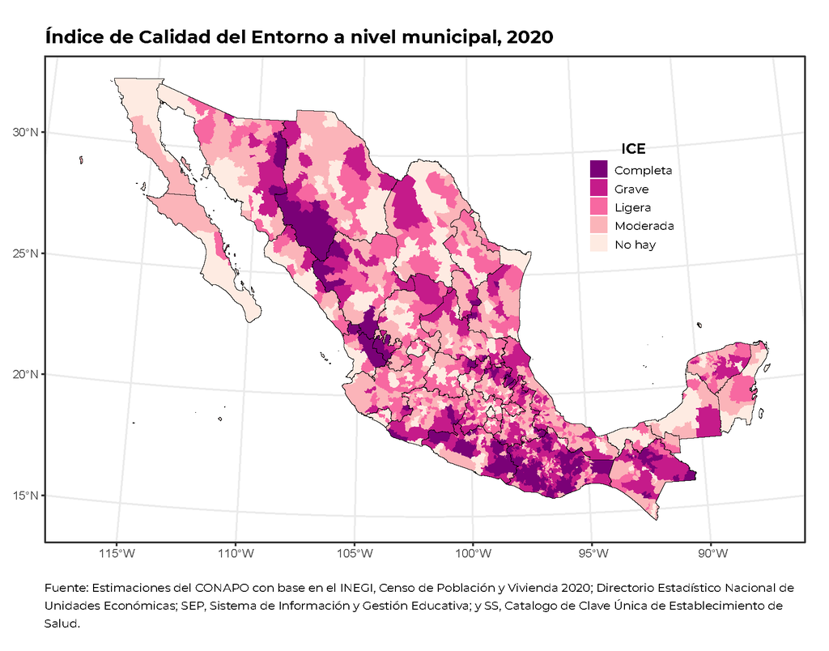

```r
# Paleta de colores
require(RColorBrewer)
require(ggspatial)
require(ggpubr)

values = rev(brewer.pal(5, "RdPu"))

p <- ggplot() +
      layer_spatial(layer_municipios, aes(fill = G_ICE), color = "transparent") +
       layer_spatial(shape_estados, fill = "transparent", color = "black") +
        theme_bw() +
         theme(plot.title = element_text(size = 22, hjust = 0.15, family = "Montserrat", face = "bold"),
               plot.caption = element_text(size = 11, hjust = 0.2, vjust = 1, family = "Montserrat"),
               legend.key.size = unit(0.5, "cm"),
               legend.text = element_text(size = 12, family = "Montserrat"),
               legend.title = element_text(size = 10, hjust = 0.5, family = "Montserrat", face = "bold"),
               legend.position = "right"
               ) +
          scale_fill_manual(values = values) +
           scale_color_manual(values = c("#BDBDBD")) +
            #guides(color = guide_legend(override.aes = list(fill = usecol(pal = pal_petrol, n = 5)))) +
     labs(title = "Índice de Calidad del Entorno a nivel municipal, 2020",
           fill = stringr::str_wrap("ICE", 10),
            caption = stringr::str_wrap(paste("Fuente: Estimaciones del CONAPO con base en el INEGI, Censo de Población y Vivienda 2020 y Directorio Estadístico Nacional de Unidades Económicas; SEP, Sistema de Información y Gestión Educativa; y SS, Catálogo de Clave Única de Establecimientos de Salud."), 100))
p
#path = "Output/Mapa del ICE a nivel municipal.pdf"
#ggexport(p, filename = path ,width = 10, height = 10, device = "cairo")
```

**Índice de Marginación 2020**

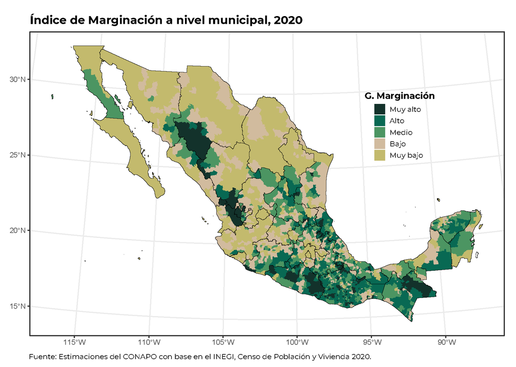

```r
# Paleta de colores
require(RColorBrewer)
require(ggspatial)
require(ggpubr)

values =   c("#13322B", #Muy alto
             "#086953", #Alto
             "#4C9562", #Medio
             "#D1BB9E", #Bajo
             "#C3BA6D") # Muy bajo

p <- ggplot() +
      layer_spatial(layer_municipios, aes(fill = GM_2020), color = "transparent") +
       layer_spatial(shape_estados, fill = "transparent", color = "black") +
        theme_bw() +
         theme(plot.title = element_text(size = 22, hjust = 0.15, family = "Montserrat", face = "bold"),
               plot.caption = element_text(size = 11, hjust = 0.2, vjust = 1, family = "Montserrat"),
               legend.key.size = unit(0.5, "cm"),
               legend.text = element_text(size = 9, family = "Montserrat"),
               legend.title = element_text(size = 10, hjust = 0.5, family = "Montserrat", face = "bold"),
               legend.position = "right"
               ) +
          scale_fill_manual(values = values) +
           scale_color_manual(values = c("#BDBDBD")) +
            #guides(color = guide_legend(override.aes = list(fill = usecol(pal = pal_petrol, n = 5)))) +
     labs(title = "Índice de Marginación a nivel municipal, 2020",
           fill = stringr::str_wrap("G. Marginación", 15),
            caption = stringr::str_wrap(paste("Fuente: Estimaciones del CONAPO con base en el INEGI, Censo de Población y Vivienda 2020."), 100))
p
#path = "Output/Mapa del índice de marginación municipal.pdf"
#ggexport(p, filename = path ,width = 10, height = 10, device = "cairo")
```

**Índice de Equipamiento**

[figure not shown]

```r
# Paleta de colores
require(RColorBrewer)
require(ggspatial)
require(ggpubr)

values =   rev(brewer.pal(5, "Blues"))
"#08519C" "#3182BD" "#6BAED6" "#BDD7E7" "#EFF3FF"
p <- ggplot() +
      layer_spatial(layer_municipios, aes(fill = G_IE), color = "transparent") +
       layer_spatial(shape_estados, fill = "transparent", color = "black") +
        theme_bw() +
         theme(plot.title = element_text(size = 22, hjust = 0.15, family = "Montserrat", face = "bold"),
               plot.caption = element_text(size = 11, hjust = 0.2, vjust = 1, family = "Montserrat"),
               legend.key.size = unit(0.5, "cm"),
               legend.text = element_text(size = 9, family = "Montserrat"),
               legend.title = element_text(size = 10, hjust = 0.5, family = "Montserrat", face = "bold"),
               legend.position = "right"
               ) +
          scale_fill_manual(values = values) +
           scale_color_manual(values = c("#BDBDBD")) +
            #guides(color = guide_legend(override.aes = list(fill = usecol(pal = pal_petrol, n = 5)))) +
     labs(title = "Índice de Equipamiento a nivel municipal, 2020",
           fill = stringr::str_wrap("G. Equipamiento", 15),
            caption = stringr::str_wrap(paste("Fuente: Estimaciones del CONAPO con base en el INEGI, Directorio Estadístico Nacional de Unidades Económicas; SEP, Sistema de Información y Gestión Educativa; y SS, Catálogo de Clave Única de Establecimientos de Salud."), 100))
p
#path = "Output/Mapa del índice de equipamiento municipal.pdf"
#ggexport(p, filename = path ,width = 10, height = 10, device = "cairo")
```

**Índice de Accesibilidad**

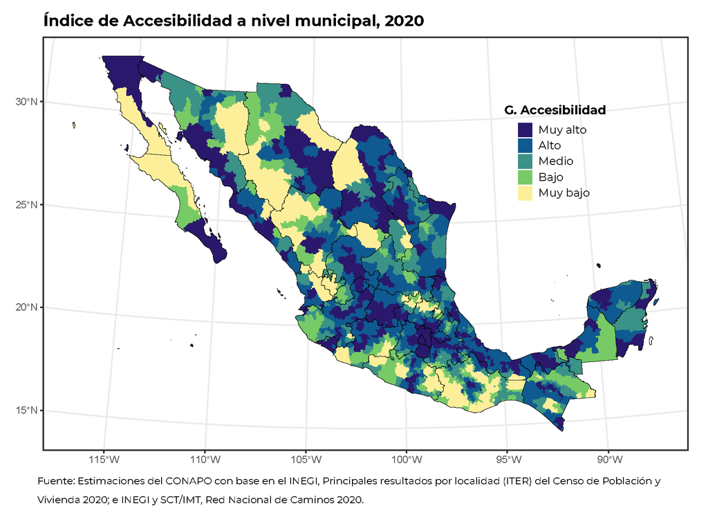

```r
# Paleta de colores
require(RColorBrewer)
require(ggspatial)
require(ggpubr)

values =  pals::ocean.haline(5)
#values = rev(c("#1A0086", "#1F42D5", "#4B9B41", "#C0CC23", "#f7e65a"))
 "#2A186C" "#0F5A90" "#3B9287" "#78CA66" "#FDEF9A"
p <- ggplot() +
      layer_spatial(layer_municipios, aes(fill = GACC), color = "transparent") +
       layer_spatial(shape_estados, fill = "transparent", color = "black") +
        theme_bw() +
         theme(plot.title = element_text(size = 22, hjust = 0.15, family = "Montserrat", face = "bold"),
               plot.caption = element_text(size = 11, hjust = 0.2, vjust = 1, family = "Montserrat"),
               legend.key.size = unit(0.5, "cm"),
               legend.text = element_text(size = 9, family = "Montserrat"),
               legend.title = element_text(size = 10, hjust = 0.5, family = "Montserrat", face = "bold"),
               legend.position = "right"
               ) +
          scale_fill_manual(values = values) +
           scale_color_manual(values = c("#BDBDBD")) +
            #guides(color = guide_legend(override.aes = list(fill = usecol(pal = pal_petrol, n = 5)))) +
     labs(title = "Índice de Accesibilidad a nivel municipal, 2020",
           fill = stringr::str_wrap("G. Accesibilidad", 20),
            caption = stringr::str_wrap(paste("Fuente: Estimaciones del CONAPO con base en el INEGI, Principales resultados por
localidad (ITER) del Censo de Población y Vivienda 2020; e INEGI y SCT/IMT. Red Nacional de Caminos 2020."), 100))
p
#path = "Output/Mapa del índice de accesibilidad.pdf"
#ggexport(p, filename = path ,width = 10, height = 10, device = "cairo")
```

## Localidad

### Base de datos

La base de datos del índice de calidad del entorno por localidades se encuentra disponible en la página oficial de [CONAPO](https://www.gob.mx/conapo/documentos/indice-de-calidad-del-entorno?idiom=es) o bien se puede consultar en la página de [Datos Abiertos](https://datos.gob.mx/) y se presenta en formato `.xlsx` [Consulta](http://www.conapo.gob.mx/work/models/CONAPO/Datos_Abiertos/DT/ICE_2020.zip).

```r
data <- read_xlsx(paste0(here::here(), "/Bases/Indice de calidad del entorno a nivel localidad.xlsx"), sheet = "ICE_2020") %>%
          mutate(CVE_GEO = CVE_LOC) %>%
           as.data.frame() %>%
            filter(ICE >= 0)
```

### SpatialPolygons

#### $$SpatialPolygons \Rightarrow SpatialPolygons + Datos$$

```r
layer_localicad <- spdplyr:::inner_join.Spatial(shape_localidad,
                                                data %>% dplyr::select(c(-CVE_LOC)) %>%
                                                               mutate(G_ICE = fct_relevel(.$G_ICE,"Muy alto", "Alto", "Medio", "Bajo", "Muy bajo"),
                                                                      GM_2020 = fct_relevel(.$GM_2020, "Muy alto", "Alto", "Medio", "Bajo", "Muy bajo"),
                                                                      G_IE = fct_relevel(.$G_IE, "Muy alto", "Alto", "Medio", "Bajo", "Muy bajo"),
                                                                      GACC = fct_relevel(.$GACC, "Muy alto (menos de 30 min)", "Alto (de 31 a 60 min)", "Medio (de 61 a 90 min)", "Bajo (de 91 a 120 min)", "Muy  bajo (más de 120 min)", "Sin localización en la red")),
                                                  by = "CVE_GEO")

layer_localicad_p <- spdplyr:::inner_join.Spatial(shape_localidad_p,
                                                  data %>% dplyr::select(c(-CVE_LOC)) %>%
                                                               mutate(G_ICE = fct_relevel(.$G_ICE,"Muy alto", "Alto", "Medio", "Bajo", "Muy bajo"),
                                                                      GM_2020 = fct_relevel(.$GM_2020, "Muy alto", "Alto", "Medio", "Bajo", "Muy bajo"),
                                                                      G_IE = fct_relevel(.$G_IE, "Muy alto", "Alto", "Medio", "Bajo", "Muy bajo"),
                                                                     GACC = fct_relevel(.$GACC, "Muy alto (menos de 30 min)", "Alto (de 31 a 60 min)", "Medio (de 61 a 90 min)", "Bajo (de 91 a 120 min)", "Muy  bajo (más de 120 min)", "Sin localización en la red")),
                                                  by = "CVE_GEO")

table(layer_localicad@data$GACC)
table(layer_localicad_p@data$GACC)
```

**Índice de Calidad del Entorno**

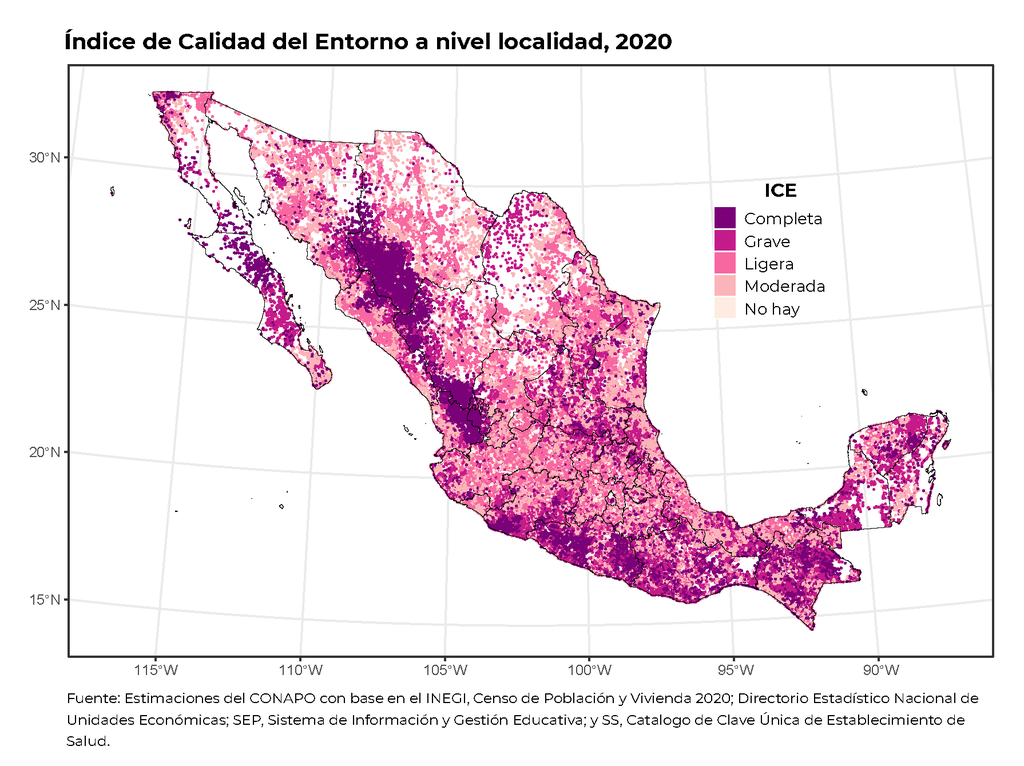

```r
# Paleta de colores
require(RColorBrewer)
require(ggspatial)
require(ggpubr)

values = rev(brewer.pal(5, "RdPu"))

p <- ggplot() +
      layer_spatial(layer_localicad, aes(fill = G_ICE), color = "transparent") +
       layer_spatial(layer_localicad_p, aes(color = G_ICE), size = 0.2) +
        layer_spatial(shape_estados, fill = "transparent", color = "black") +
         theme_bw() +
          theme(plot.title = element_text(size = 22, hjust = 0.15, family = "Montserrat", face = "bold"),
                plot.caption = element_text(size = 11, hjust = 0.2, vjust = 1, family = "Montserrat"),
                legend.key.size = unit(0.5, "cm"),
                legend.text = element_text(size = 12, family = "Montserrat"),
                legend.title = element_text(size = 10, hjust = 0.5, family = "Montserrat", face = "bold"),
                legend.position = "right"
                ) +
           scale_fill_manual(values = values) +
            scale_color_manual(values = values) +
            #guides(color = guide_legend(override.aes = list(fill = usecol(pal = pal_petrol, n = 5)))) +
     labs(title = "Índice de Calidad del Entorno a nivel localidad, 2020",
          fill = stringr::str_wrap("ICE", 10),
          color = stringr::str_wrap("ICE", 10),
          caption = stringr::str_wrap(paste("Fuente: Estimaciones del CONAPO con base en el INEGI, Censo de Población y Vivienda 2020 y Directorio Estadístico Nacional de Unidades Económicas; SEP, Sistema de Información y Gestión Educativa; y SS, Catálogo de Clave Única de Establecimientos de Salud."), 100))

p

#path = "Output/Mapa del ICE a nivel localidad.pdf"
#ggexport(p, filename = path ,width = 10, height = 10, device = "cairo")
```

**Índice de Marginación 2020**

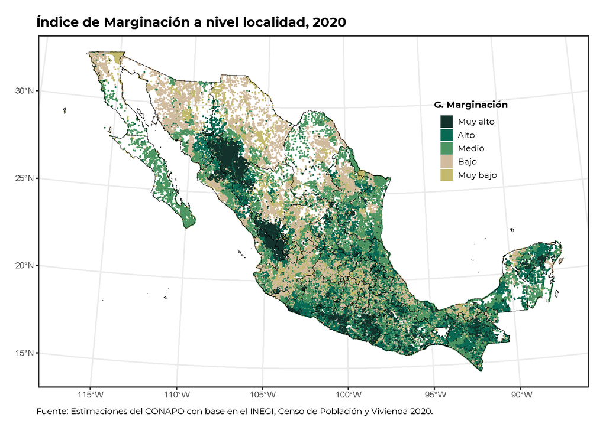

```r
# Paleta de colores
require(RColorBrewer)
require(ggspatial)
require(ggpubr)

values =   c("#13322B", #Muy alto
             "#086953", #Alto
             "#4C9562", #Medio
             "#D1BB9E", #Bajo
             "#C3BA6D") # Muy bajo

p <- ggplot() +
      layer_spatial(layer_localicad %>% filter(IM_2020 >= 0), aes(fill = GM_2020), color = "transparent") +
       layer_spatial(layer_localicad_p %>% filter(IM_2020 >= 0), aes(color = GM_2020), size = 0.2) +
        layer_spatial(shape_estados, fill = "transparent", color = "black") +
         theme_bw() +
          theme(plot.title = element_text(size = 22, hjust = 0.15, family = "Montserrat", face = "bold"),
                plot.caption = element_text(size = 11, hjust = 0.2, vjust = 1, family = "Montserrat"),
                legend.key.size = unit(0.5, "cm"),
                legend.text = element_text(size = 9, family = "Montserrat"),
                legend.title = element_text(size = 10, hjust = 0.5, family = "Montserrat", face = "bold"),
                legend.position = "right"
                ) +
           scale_fill_manual(values = values) +
            scale_color_manual(values = values) +
            #guides(color = guide_legend(override.aes = list(fill = usecol(pal = pal_petrol, n = 5)))) +
     labs(title = "Índice de Marginación a nivel localidad, 2020",
          fill = stringr::str_wrap("G. Marginación", 15),
          color = stringr::str_wrap("G. Marginación", 15),
          caption = stringr::str_wrap(paste("Fuente: Estimaciones del CONAPO con base en el INEGI, Censo de Población y Vivienda 2020."), 100))
p
#path = "Output/Mapa del índice de marginación localidad.pdf"
#ggexport(p, filename = path ,width = 10, height = 10, device = "cairo")
```

**Índice de Equipamiento**

[figure not shown]

```r
# Paleta de colores
require(RColorBrewer)
require(ggspatial)
require(ggpubr)

values =   rev(brewer.pal(5, "Blues"))

p <- ggplot() +
      layer_spatial(layer_localicad %>% filter(IE >= 0), aes(fill = G_IE), color = "transparent") +
       layer_spatial(layer_localicad_p %>% filter(IE >= 0), aes(color = G_IE), size = 0.2) +
        layer_spatial(shape_estados, fill = "transparent", color = "black") +
         theme_bw() +
          theme(plot.title = element_text(size = 22, hjust = 0.15, family = "Montserrat", face = "bold"),
                plot.caption = element_text(size = 11, hjust = 0.2, vjust = 1, family = "Montserrat"),
                legend.key.size = unit(0.5, "cm"),
                legend.text = element_text(size = 9, family = "Montserrat"),
                legend.title = element_text(size = 10, hjust = 0.5, family = "Montserrat", face = "bold"),
                legend.position = "right"
                ) +
           scale_fill_manual(values = values) +
            scale_color_manual(values = values) +
            #guides(color = guide_legend(override.aes = list(fill = usecol(pal = pal_petrol, n = 5)))) +
      labs(title = "Índice de Equipamiento a nivel localidad, 2020",
           fill = stringr::str_wrap("G. Equipamiento", 15),
           color = stringr::str_wrap("G. Equipamiento", 15),
           caption = stringr::str_wrap(paste("Fuente: Estimaciones del CONAPO con base en el INEGI, Directorio Estadístico Nacional de Unidades Económicas; SEP, Sistema de Información y Gestión Educativa; y SS, Catálogo de Clave Única de Establecimientos de Salud."), 100))
p
path = "Output/Mapa del índice de equipamiento localidad.pdf"
ggexport(p, filename = path ,width = 10, height = 10, device = "cairo")
```

**Índice de Accesibilidad**

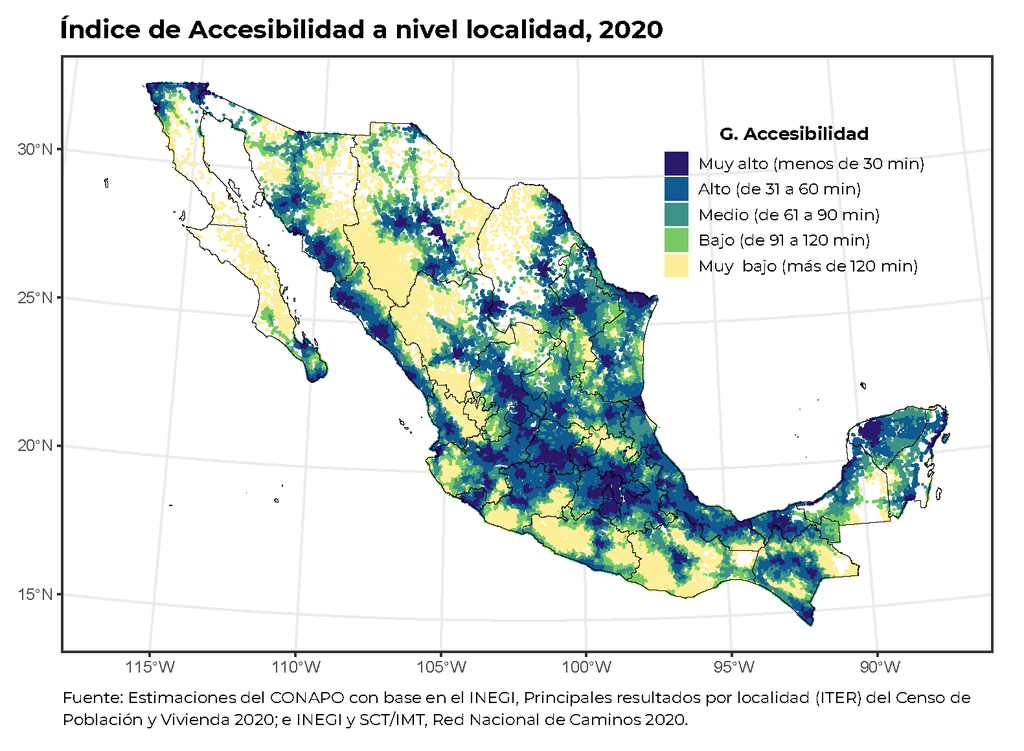

```r
# Paleta de colores
require(RColorBrewer)
require(ggspatial)
require(ggpubr)

values =  pals::ocean.haline(5)
#values = rev(c("#1A0086", "#1F42D5", "#4B9B41", "#C0CC23", "#f7e65a"))

p <- ggplot() +
      layer_spatial(layer_localicad %>% filter(IAL >= 0), aes(fill = GACC), color = "transparent") +
       layer_spatial(layer_localicad_p %>% filter(IAL >= 0), aes(color = GACC), size = 0.2) +
        layer_spatial(shape_estados, fill = "transparent", color = "black") +
         theme_bw() +
          theme(plot.title = element_text(size = 22, hjust = 0.15, family = "Montserrat", face = "bold"),
                plot.caption = element_text(size = 11, hjust = 0.2, vjust = 1, family = "Montserrat"),
                legend.key.size = unit(0.5, "cm"),
                legend.text = element_text(size = 9, family = "Montserrat"),
                legend.title = element_text(size = 10, hjust = 0.5, family = "Montserrat", face = "bold"),
                legend.position = "right"
                ) +
           scale_fill_manual(values = values) +
            scale_color_manual(values = values) +
            #guides(color = guide_legend(override.aes = list(fill = usecol(pal = pal_petrol, n = 5)))) +
     labs(title = "Índice de Accesibilidad a nivel localidad, 2020",
          fill = stringr::str_wrap("G. Accesibilidad", 20),
          color = stringr::str_wrap("G. Accesibilidad", 20),
          caption = stringr::str_wrap(paste("Fuente: Estimaciones del CONAPO con base en el INEGI, Principales resultados por
localidad (ITER) del Censo de Población y Vivienda 2020; e INEGI y SCT/IMT. Red Nacional de Caminos 2020."), 100))
p
#path = "Output/Mapa del índice de accesibilidad localidad.pdf"
#ggexport(p, filename = path ,width = 10, height = 10, device = "cairo")
```

## Librerías

**Librerías que se usaron en el trabajo**

```r
sesion_info <- devtools::session_info()
```

This work by **Diana Villasana Ocampo** is licensed under a [Creative Commons Attribution 4.0 International License](http://creativecommons.org/licenses/by/4.0/).